# Lab 1: Intro to R

## Exercise 4

### Loading Present Data Set:

```r
present
```

```
## # A tibble: 63 × 3
##     year    boys   girls
##    <dbl>   <dbl>   <dbl>
##  1  1940 1211684 1148715
##  2  1941 1289734 1223693
##  3  1942 1444365 1364631
##  4  1943 1508959 1427901
##  5  1944 1435301 1359499
##  6  1945 1404587 1330869
##  7  1946 1691220 1597452
##  8  1947 1899876 1800064
##  9  1948 1813852 1721216
## 10  1949 1826352 1733177
## # ℹ 53 more rows
```

```r
present %>%
summarize(min = min(boys),
max = max(boys)
)
```

```
## # A tibble: 1 × 2
##       min     max
##     <dbl>   <dbl>
## 1 1211684 2186274
```

**What years are included in this data set? What are the dimensions of the data frame? What are the variable (column) names?**

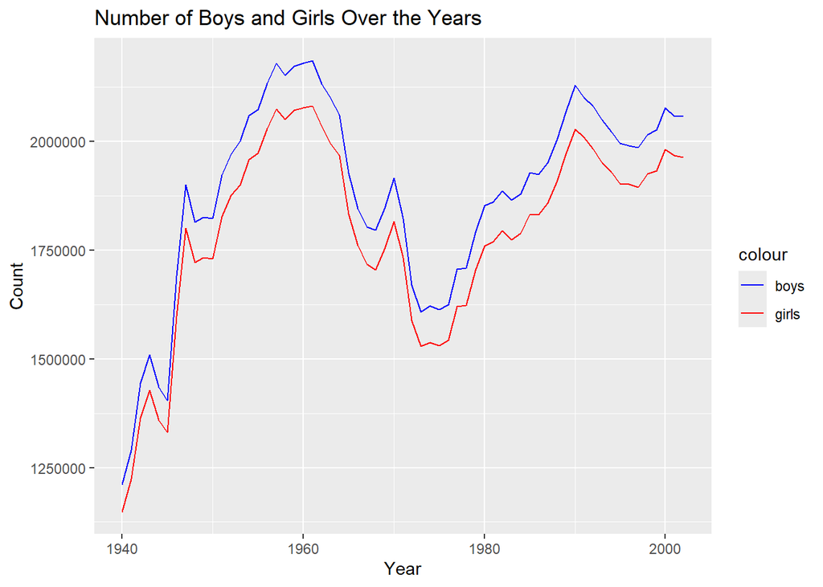

```r
# Plotting boys and girls on the same plot with different colors
ggplot(data = present, aes(x = year)) +
  geom_line(aes(y = boys, color = "boys")) +
  geom_line(aes(y = girls, color = "girls")) +
  scale_color_manual(values = c("boys" = "blue", "girls" = "red")) +
  labs(title = "Number of Boys and Girls Over the Years",
       x = "Year",
       y = "Count",
       legend="color")
```

1. In the data set the years from 1940 - early 2000’s were included.

```r
present
```

```
## # A tibble: 63 × 3
##     year    boys   girls
##    <dbl>   <dbl>   <dbl>
##  1  1940 1211684 1148715
##  2  1941 1289734 1223693
##  3  1942 1444365 1364631
##  4  1943 1508959 1427901
##  5  1944 1435301 1359499
##  6  1945 1404587 1330869
##  7  1946 1691220 1597452
##  8  1947 1899876 1800064
##  9  1948 1813852 1721216
## 10  1949 1826352 1733177
## # ℹ 53 more rows
```

2. The data frame has **63 rows and 3 columns** namely year,boys and girls.
3. Here we have three variable columns **year, boys and girls**

## Exercise 5

**How do these counts compare to Arbuthnot’s? Are they of a similar magnitude?**

```r
# Insert code for Exercise 5 here
#present$boys + present$girls
present <- present %>%
mutate(total = boys + girls)
present %>% summarize(min = min(total),max = max(total))
```

```
## # A tibble: 1 × 2
##       min     max
##     <dbl>   <dbl>
## 1 2360399 4268326
```

```r
arbuthnot %>% summarize(min=min(total2),max=max(total2))
```

```
## # A tibble: 1 × 2
##     min   max
##   <int> <int>
## 1  5612 16145
```

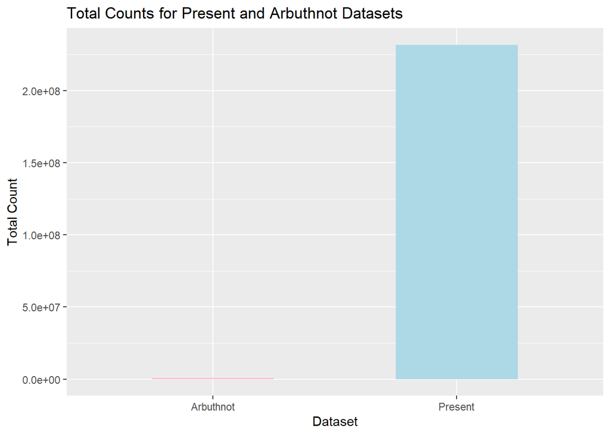

```r
# Calculate total sums for present and arbuthnot datasets
present_total <- present %>% summarize(total_sum = sum(total))
arbuthnot_total <- arbuthnot %>% summarize(total_sum = sum(total2))

# Combine the results into a format suitable for ggplot2
ggplot() +
  geom_bar(aes(x = "Present", y = present_total$total_sum), stat = "identity", fill = "lightblue", width = 0.5) +
  geom_bar(aes(x = "Arbuthnot", y = arbuthnot_total$total_sum), stat = "identity", fill = "pink", width = 0.5) +
  labs(title = "Total Counts for Present and Arbuthnot Datasets",
       x = "Dataset",
       y = "Total Count")
```

Based on the above graph we can say that the magnitude of the present is way more higher than that of the arbuthnot.

## Exercise 6

**Make a plot that displays the proportion of boys born over time. What do you see? Does Arbuthnot’s observation about boys being born in greater proportion than girls hold up in the U.S.? Include the plot in your response. Hint: You should be able to reuse your code from Exercise 3 above, just replace the name of the data frame.**

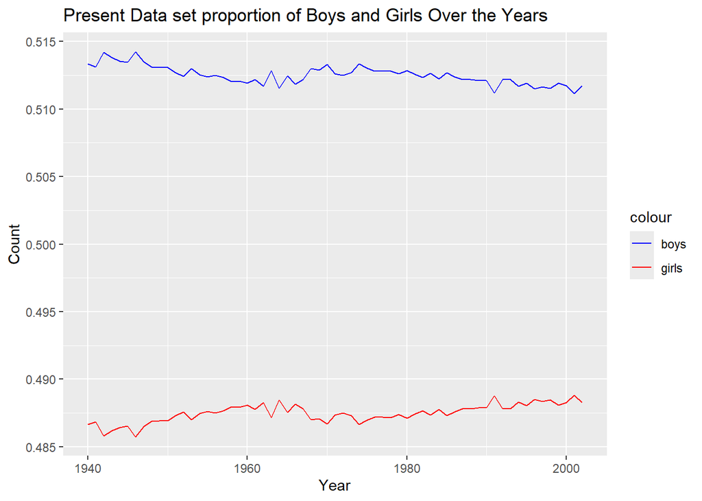

```r
# Insert code for Exercise 6 here
present <- present %>%
mutate(present_boy_ratio = boys/total)
present <- present %>%
mutate(present_girl_ratio=girls/total)

ggplot(data = present, aes(x = year)) +
  geom_line(aes(y = present_boy_ratio, color = "boys")) +
  geom_line(aes(y = present_girl_ratio, color = "girls")) +
  scale_color_manual(values = c("boys" = "blue", "girls" = "red")) +
  labs(title = "Present Data set proportion of Boys and Girls Over the Years",
       x = "Year",
       y = "Count",
       legend="color")
```

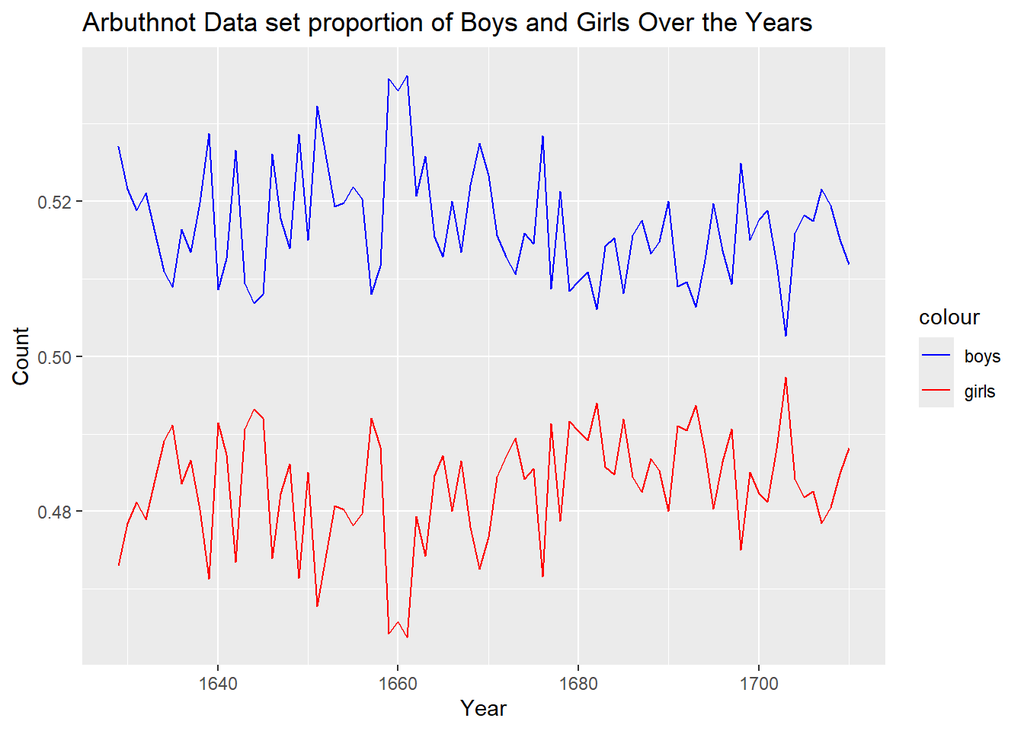

```r
ggplot(data = arbuthnot, aes(x = year)) +
  geom_line(aes(y = boy_ratio_2, color = "boys")) +
  geom_line(aes(y = girl_ratio, color = "girls")) +
  scale_color_manual(values = c("boys" = "blue", "girls" = "red")) +
  labs(title = "Arbuthnot Data set proportion of Boys and Girls Over the Years",
       x = "Year",
       y = "Count",
       legend="color")
```

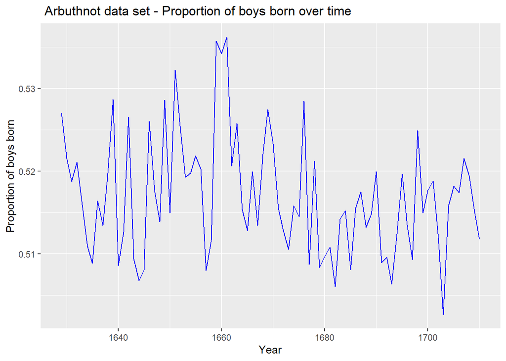

```r
ggplot(data = arbuthnot, aes(x = year, y = boy_ratio_2)) +geom_line(color='blue')+labs(title = " Arbuthnot data set - Proportion of boys born over time",x = "Year",y = "Proportion of boys born")
```

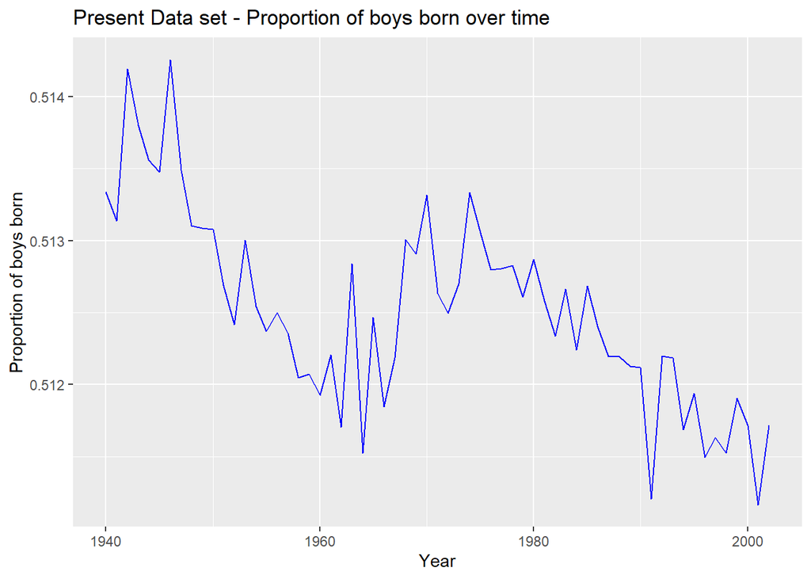

```r
ggplot(data = present, aes(x = year, y = present_boy_ratio)) +geom_line(color='blue')+labs(title = "Present Data set - Proportion of boys born over time",x = "Year",y = "Proportion of boys born")
```

- Based on the first two graphs we can say that the **proportion of boys** is always **greater compared to girls in both the Arbuthnot and present data set.** - While comparing induvidually we can observe that the **proportion of boys being born in Arbuthnot data set is greater/higher compared to present Data set** - There is a **decline in the boy_ratio in the present data set.**

## Exercise 7

**In what year did we see the most total number of births in the U.S.?**

```r
# Insert code for Exercise 7 here
present %>%
arrange(desc(total))
```

```
## # A tibble: 63 × 6
##     year    boys   girls   total present_boy_ratio present_girl_ratio
##    <dbl>   <dbl>   <dbl>   <dbl>             <dbl>              <dbl>
##  1  1961 2186274 2082052 4268326             0.512              0.488
##  2  1960 2179708 2078142 4257850             0.512              0.488
##  3  1957 2179960 2074824 4254784             0.512              0.488
##  4  1959 2173638 2071158 4244796             0.512              0.488
##  5  1958 2152546 2051266 4203812             0.512              0.488
##  6  1962 2132466 2034896 4167362             0.512              0.488
##  7  1956 2133588 2029502 4163090             0.513              0.487
##  8  1990 2129495 2028717 4158212             0.512              0.488
##  9  1991 2101518 2009389 4110907             0.511              0.489
## 10  1963 2101632 1996388 4098020             0.513              0.487
## # ℹ 53 more rows
```

In the year 1961 we saw the most total number of births in the U.S.

reference:

- for plotting two line plots in a single graph i learnt and picked up the code from (This website)[https://forum.posit.co/t/plotting-multiple-line/37056]